# Blackgill Rockfish

*Sebastes melanostomus*

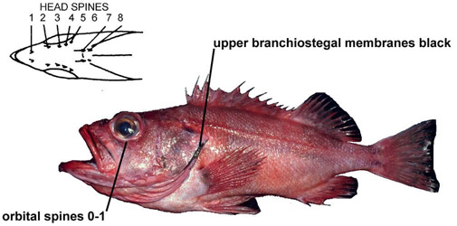

**Body color:** Uniform dark red, including fins; dusky bars may be present on back, these prominent in young specimens; most fins w/ blackened tips.

**Peritoneum color:** black **Shape between eyes:** flat to convex

**Counts:** D:XIII,12-15, Ar:6-8, P1:17-20, GR:27-34, LLp:28-34, LLs:32-34, V:26

**Occurence:** Washington - Baja California

**Depth:** 768 meters **Size:** 61 cm **Species code:** 30340

**Similar species:**

- *Shortraker rockfish* - body pink or orange-pink; mouth, branchiostegal membranes, and gill cavity red to red-black; peritoneum light w/ black spots; gillrakers 27-31 (typically 30-34 in Blackgill RF)
- *Rougheye rockfish* - 2-10 spines below eye; mouth, branchiostegal membranes, and gill cavity red to red-black; peritoneum light
- *Pacific Ocean Perch* - head spines weak and differ in count; dark blotches discrete at dorsal base; symphyseal knob prominent
- *Sharpchin rockfish* - symphyseal knob prominent; discrete blotches w/ at least one crossing lateral line; head spines differ in count; anal spine 2 longer than 3

Back to Group

**Corrections:** If you see mistakes or want to suggest changes, please create an [issue](https://github.com/zoyafuso-NOAA/RACE_Survey_App/issues) on the source repository or

*reach out to Liz Dawson (Liz.Dawson AT noaa.gov).*